# Environmental Resource Consumption and Service Demand in Melbourne

Authored by: Mengkheang Neak

**Duration:** 90 mins  
**Level:** Intermediate  
**Pre-requisite Skills:** Python, Data Analysis, Visualization, Temporal Analysis, Correlation Analysis

## **Scenario**

I am tasked with analyzing customer service request trends and their relationship with resource consumption and planned capital works in the City of Melbourne. The goal is to uncover operational inefficiencies, identify patterns in resource consumption, and evaluate environmental impacts to optimize city management practices. By aligning service operations with sustainable resource use, this analysis aims to provide actionable recommendations for improving service delivery, resource allocation, and environmental sustainability.

## **What This Use Case Will Teach You**

At the end of this use case, you will:

- Understand how to clean and preprocess datasets for service requests and resource consumption.
- Perform exploratory data analysis (EDA) to extract trends and seasonal insights.
- Identify correlations between service requests, resource consumption, and emissions.
- Conduct seasonal and temporal trend analysis to uncover operational patterns.
- Investigate anomalies in resource usage and emissions.
- Develop actionable insights and recommendations for optimizing urban management practices.
- Create a data-driven framework for aligning resource allocation with service demand.

## **Background and Introduction**

Environmental sustainability is a critical focus for the City of Melbourne, particularly in aligning service delivery with efficient resource consumption. This project investigates the patterns and correlations between **customer service requests**, **environmental resource consumption**, and **planned capital works**, with a view toward improving operational efficiency and environmental sustainability.

By analyzing these datasets, this use case highlights key areas for improvement, identifies misalignments in resource usage, and provides data-driven recommendations to enhance city operations. Seasonal and temporal patterns are explored to optimize resource allocation and reduce the city's environmental footprint.

## **Datasets Used**

1. **Customer Service Requests with Resolution Time**: Includes details on service categories, resolution timelines, and geographic data for various customer service requests in Melbourne.
2. **Environmental Resources Consumed**: Contains data on electricity, fuel, chemicals, air travel, and their corresponding greenhouse gas emissions.
3. **Planned Capital Works and Maintenance**: Provides information on infrastructure projects, funding sources, and project details.

These datasets are sourced from public data provided by the City of Melbourne.

## **Implementation**

### **Step 1: Data Cleaning and Preprocessing**

- Load and inspect the datasets.
- Clean and preprocess the data to handle missing or inconsistent values.
- Integrate datasets to establish a unified analysis framework.

### **Step 2: Exploratory Data Analysis (EDA)**

- Generate summary statistics for key metrics, including service requests, resource usage, and emissions.
- Analyze service categories and their geographic distribution.
- Visualize patterns in resource consumption and emissions over time.

### **Step 3: Temporal and Seasonal Analysis**

- Identify seasonal trends in **service requests** and **resource consumption**.
- Analyze the correlation between service demand and resource usage.
- Investigate anomalies, such as the resource spikes observed in **July 2013**.

### **Step 4: Cross-Analysis of Service Requests and Resource Usage**

- Compare seasonal trends in **service demand** with **resource consumption**.
- Evaluate the alignment between high-demand periods and resource-intensive activities.
- Quantify correlations between requests, resource usage, and emissions.

### **Step 5: Investigation of Resource Anomalies**

- Focus on resource and emission spikes in **July 2013** and other anomalous periods.
- Investigate potential causes such as large-scale infrastructure projects or special events.
- Cross-reference resource patterns with planned capital works data.

### **Step 6: Strategic Recommendations**

- Provide actionable insights to optimize resource allocation based on seasonal service demand.
- Suggest operational changes to align resource consumption with service delivery.
- Develop sustainability-focused strategies to reduce greenhouse gas emissions.

## **Conclusion**

By following this use case, you will:

- Gain a detailed understanding of the relationship between service delivery and environmental sustainability.
- Identify inefficiencies in resource allocation and service demand alignment.
- Provide data-driven recommendations for improving urban management practices.
- Contribute to Melbourne’s goals for operational efficiency and environmental sustainability.

The actionable insights derived from this analysis will empower the City of Melbourne to align service delivery with sustainable resource use, contributing to a more livable and environmentally friendly city.

```python
import requests
import pandas as pd
import os
from io import StringIO
import matplotlib.pyplot as plt
import seaborn as sns
```

```python
def API_Unlimited(datasetname): # pass in dataset name and api key
    dataset_id = datasetname

    base_url = 'https://data.melbourne.vic.gov.au/api/explore/v2.1/catalog/datasets/'
    #apikey = api_key
    dataset_id = dataset_id
    format = 'csv'

    url = f'{base_url}{dataset_id}/exports/{format}'
    params = {
        'select': '*',
        'limit': -1,  # all records
        'lang': 'en',
        'timezone': 'UTC'
    }

    # GET request
    response = requests.get(url, params=params)

    if response.status_code == 200:
        # StringIO to read the CSV data
        url_content = response.content.decode('utf-8')
        datasetname = pd.read_csv(StringIO(url_content), delimiter=';')
        print(datasetname.sample(10, random_state=999)) # Test
        return datasetname
    else:
        return (print(f'Request failed with status code {response.status_code}'))


download_link_1 = 'customer-service-requests-with-resolution-time'
download_link_2 = 'environmental-resources-consumed-including-air-travel-chemicals-electricity-fuel'
download_link_3 = 'planned-capital-works-and-maintenance-2014-15-with-funding-sources'


# Use functions to download and load data
customer_service_df = API_Unlimited(download_link_1)
environmental_resources_df = API_Unlimited(download_link_2)
capital_works_df = API_Unlimited(download_link_3)
```

```
      request_status date_received date_completed      suburb  \
22471         CLOSED    2016-06-14     2016-06-14         NaN
4040          CLOSED    2016-02-16     2016-02-17   Parkville
23604         CLOSED    2015-05-13     2015-05-20   Melbourne
3143          CLOSED    2015-04-22     2015-04-23         NaN
14416         CLOSED    2016-09-12     2016-10-12   Melbourne
39708         CLOSED    2015-07-21     2015-07-29         NaN
31267         CLOSED    2014-12-19     2015-02-23  Kensington
33638         CLOSED    2016-05-04     2016-05-17  Kensington
44158         CLOSED    2016-06-28     2016-07-11         NaN
46129         CLOSED    2016-05-17     2016-05-18         NaN

                                category           service_desc  \
22471  Waste, Street Cleaning and Litter           Damaged Bins
4040   Waste, Street Cleaning and Litter  Missed Bin Collection
```

[output cut: 150 more lines]

# Data Cleaning and Preprocessing

To ensure the datasets were properly prepared for analysis, a detailed data cleaning process was conducted. The primary focus was on addressing inconsistencies, handling missing data, and standardizing the structure for effective analysis.

### **Results of Cleaning**

#### **Customer Service Requests Dataset**:

- Final dataset contains **21,310 entries** with all key metrics cleaned and ready for analysis.
- Examples of key fields:
  - `category` (e.g., Waste Management, Graffiti),
  - `days_to_complete` (resolution time in days), and
  - `suburb` (geographical focus).

#### **Environmental Resources Dataset**:

- Cleaned to **9,474 entries** with numeric values for resource consumption and emissions filled accurately.
- Fields like `amount` and `total_greenhouse_gases_(t_co2-e)` are now ready for correlation and temporal analysis.

#### **Planned Capital Works Dataset**:

- Reduced to **133 entries**, ensuring financial and project descriptions are properly formatted.
- Includes details like `expenditure_type`, `program`, and `total_funding`, providing insights into infrastructure investments.

### **Prepared for Analysis**

After cleaning, all datasets are ready for in-depth analyses, including:

- Exploring seasonal trends in service requests.
- Analyzing environmental impacts of resource usage.
- Evaluating correlations between service demands, resource consumption, and planned infrastructure spending.

This structured data preparation ensures accurate and actionable insights in the subsequent analysis stages.

```python
# Display the first few rows of each dataset to understand their structure
print("Customer Service Requests Dataset:")
display(customer_service_df.head())

print("Environmental Resources Consumed Dataset:")
display(environmental_resources_df.head())

print("Planned Capital Works and Maintenance Dataset:")
display(capital_works_df.head())

# Data Cleaning Steps for Customer Service Requests Dataset
# 1. Handle missing values
# 2. Standardize column headers
# 3. Convert date/time columns to datetime format if applicable

# Clean customer service dataset
customer_service_df.columns = customer_service_df.columns.str.strip().str.replace(' ', '_').str.lower()
customer_service_df = customer_service_df.dropna()  # Drop rows with missing values
# Convert date columns to datetime if they exist (replace 'date_column' with actual column name)
# customer_service_df['date_column'] = pd.to_datetime(customer_service_df['date_column'])

# Data Cleaning Steps for Environmental Resources Consumed Dataset
# 1. Handle missing values
# 2. Standardize column headers
environmental_resources_df.columns = environmental_resources_df.columns.str.strip().str.replace(' ', '_').str.lower()
environmental_resources_df = environmental_resources_df.fillna(0)  # Replace missing values with 0 for numerical columns

# Data Cleaning Steps for Capital Works Dataset
# 1. Handle missing values
# 2. Standardize column headers
capital_works_df.columns = capital_works_df.columns.str.strip().str.replace(' ', '_').str.lower()
capital_works_df = capital_works_df.fillna('Unknown')  # Replace missing values with 'Unknown' for categorical columns

# Display cleaned datasets
print("Cleaned Customer Service Requests Dataset:")
display(customer_service_df.head())

print("Cleaned Environmental Resources Consumed Dataset:")
display(environmental_resources_df.head())

print("Cleaned Planned Capital Works and Maintenance Dataset:")
display(capital_works_df.head())
```

```
Customer Service Requests Dataset:
```

|  | request_status | date_received | date_completed | suburb | category | service_desc | days_to_complete |
| --- | --- | --- | --- | --- | --- | --- | --- |
| 0 | CLOSED | 2016-05-05 | 2016-05-12 | Carlton | Graffiti | Graffiti Removal | 7 |
| 1 | CLOSED | 2014-11-20 | 2014-11-21 | East Melbourne | Waste, Street Cleaning and Litter | Missed Bin Collection | 1 |
| 2 | CLOSED | 2014-11-27 | 2014-12-01 | Carlton | Waste, Street Cleaning and Litter | Missed Bin Collection | 4 |
| 3 | CLOSED | 2015-01-21 | 2015-01-22 | Melbourne | Waste, Street Cleaning and Litter | Street Cleaning services | 1 |
| 4 | CLOSED | 2015-01-23 | 2015-01-27 | Southbank | Waste, Street Cleaning and Litter | Damaged Bins | 4 |

```
Environmental Resources Consumed Dataset:
```

|  | branch | asset_name | resource_category | resource_type | amount | unit | total_greenhouse_gases_t_co2_e | billing_start_date | billing_end_date | com_or_supply_chain | peak_amount | off_peak_amount |
| --- | --- | --- | --- | --- | --- | --- | --- | --- | --- | --- | --- | --- |
| 0 | Community Services | Health Centre - North Melbourne | Comingled recycle | Waste | 240.0 | kg | 0.0 | 2014-02-01 | 2014-02-28 | CoM | NaN | NaN |
| 1 | Community Services | Health Centre - North Melbourne | Comingled recycle | Waste | 240.0 | kg | 0.0 | 2014-03-01 | 2014-03-31 | CoM | NaN | NaN |
| 2 | Community Services | Health Centre - North Melbourne | Comingled recycle | Waste | 120.0 | kg | 0.0 | 2014-05-01 | 2014-05-31 | CoM | NaN | NaN |
| 3 | Community Services | Health Centre - Powlett Reserve | Comingled recycle | Waste | 360.0 | kg | 0.0 | 2013-07-01 | 2013-07-31 | CoM | NaN | NaN |
| 4 | Community Services | Health Centre - Powlett Reserve | Comingled recycle | Waste | 360.0 | kg | 0.0 | 2013-08-01 | 2013-08-31 | CoM | NaN | NaN |

```
Planned Capital Works and Maintenance Dataset:
```

|  | financial_year | program | category | sub_category | expenditure_type | program_code | description | cash_000 | grants_000 | parking_levy_000 | external_000 | public_open_space_000 | proceeds_from_sale_of_assets_000 | total_funding_000 |
| --- | --- | --- | --- | --- | --- | --- | --- | --- | --- | --- | --- | --- | --- | --- |
| 0 | 2014 - 15 | CAPITAL WORKS PROGRAM | PROPERTY | BUILDING IMPROVEMENTS | Asset Renewal Expenditure | 14G3510R | Property Services Corporate Renewal Works | 1615984 | 0 | 0 | 0 | 0 | 0 | 1615984 |
| 1 | 2014 - 15 | CAPITAL WORKS PROGRAM | PROPERTY | BUILDING IMPROVEMENTS | Asset Renewal Expenditure | 14G3512R | Property Services Community Renewal Works | 843282 | 0 | 0 | 0 | 0 | 0 | 843282 |
| 2 | 2014 - 15 | CAPITAL WORKS PROGRAM | PROPERTY | HERITAGE BUILDINGS | Asset Renewal Expenditure | 14G3527R | QVM - Minor New Works | 159000 | 0 | 0 | 0 | 0 | 0 | 159000 |
| 3 | 2014 - 15 | CAPITAL WORKS PROGRAM | PLANT & EQUIPMENT | PLANT, MACHINERY & EQUIPMENT | New Asset Expenditure | 14G2811N | New Christmas Decorations - City | 250000 | 0 | 0 | 0 | 0 | 0 | 250000 |
| 4 | 2014 - 15 | CAPITAL WORKS PROGRAM | PLANT & EQUIPMENT | PLANT, MACHINERY & EQUIPMENT | New Asset Expenditure | 14G2812N | D - New Christmas Decorations -\nDocklands | 150000 | 0 | 0 | 0 | 0 | 0 | 150000 |

```
Cleaned Customer Service Requests Dataset:
```

|  | request_status | date_received | date_completed | suburb | category | service_desc | days_to_complete |
| --- | --- | --- | --- | --- | --- | --- | --- |
| 0 | CLOSED | 2016-05-05 | 2016-05-12 | Carlton | Graffiti | Graffiti Removal | 7 |
| 1 | CLOSED | 2014-11-20 | 2014-11-21 | East Melbourne | Waste, Street Cleaning and Litter | Missed Bin Collection | 1 |
| 2 | CLOSED | 2014-11-27 | 2014-12-01 | Carlton | Waste, Street Cleaning and Litter | Missed Bin Collection | 4 |
| 3 | CLOSED | 2015-01-21 | 2015-01-22 | Melbourne | Waste, Street Cleaning and Litter | Street Cleaning services | 1 |
| 4 | CLOSED | 2015-01-23 | 2015-01-27 | Southbank | Waste, Street Cleaning and Litter | Damaged Bins | 4 |

```
Cleaned Environmental Resources Consumed Dataset:
```

|  | branch | asset_name | resource_category | resource_type | amount | unit | total_greenhouse_gases_t_co2_e | billing_start_date | billing_end_date | com_or_supply_chain | peak_amount | off_peak_amount |
| --- | --- | --- | --- | --- | --- | --- | --- | --- | --- | --- | --- | --- |
| 0 | Community Services | Health Centre - North Melbourne | Comingled recycle | Waste | 240.0 | kg | 0.0 | 2014-02-01 | 2014-02-28 | CoM | 0.0 | 0.0 |
| 1 | Community Services | Health Centre - North Melbourne | Comingled recycle | Waste | 240.0 | kg | 0.0 | 2014-03-01 | 2014-03-31 | CoM | 0.0 | 0.0 |
| 2 | Community Services | Health Centre - North Melbourne | Comingled recycle | Waste | 120.0 | kg | 0.0 | 2014-05-01 | 2014-05-31 | CoM | 0.0 | 0.0 |
| 3 | Community Services | Health Centre - Powlett Reserve | Comingled recycle | Waste | 360.0 | kg | 0.0 | 2013-07-01 | 2013-07-31 | CoM | 0.0 | 0.0 |
| 4 | Community Services | Health Centre - Powlett Reserve | Comingled recycle | Waste | 360.0 | kg | 0.0 | 2013-08-01 | 2013-08-31 | CoM | 0.0 | 0.0 |

```
Cleaned Planned Capital Works and Maintenance Dataset:
```

|  | financial_year | program | category | sub_category | expenditure_type | program_code | description | cash_000 | grants_000 | parking_levy_000 | external_000 | public_open_space_000 | proceeds_from_sale_of_assets_000 | total_funding_000 |
| --- | --- | --- | --- | --- | --- | --- | --- | --- | --- | --- | --- | --- | --- | --- |
| 0 | 2014 - 15 | CAPITAL WORKS PROGRAM | PROPERTY | BUILDING IMPROVEMENTS | Asset Renewal Expenditure | 14G3510R | Property Services Corporate Renewal Works | 1615984 | 0 | 0 | 0 | 0 | 0 | 1615984 |
| 1 | 2014 - 15 | CAPITAL WORKS PROGRAM | PROPERTY | BUILDING IMPROVEMENTS | Asset Renewal Expenditure | 14G3512R | Property Services Community Renewal Works | 843282 | 0 | 0 | 0 | 0 | 0 | 843282 |
| 2 | 2014 - 15 | CAPITAL WORKS PROGRAM | PROPERTY | HERITAGE BUILDINGS | Asset Renewal Expenditure | 14G3527R | QVM - Minor New Works | 159000 | 0 | 0 | 0 | 0 | 0 | 159000 |
| 3 | 2014 - 15 | CAPITAL WORKS PROGRAM | PLANT & EQUIPMENT | PLANT, MACHINERY & EQUIPMENT | New Asset Expenditure | 14G2811N | New Christmas Decorations - City | 250000 | 0 | 0 | 0 | 0 | 0 | 250000 |
| 4 | 2014 - 15 | CAPITAL WORKS PROGRAM | PLANT & EQUIPMENT | PLANT, MACHINERY & EQUIPMENT | New Asset Expenditure | 14G2812N | D - New Christmas Decorations -\nDocklands | 150000 | 0 | 0 | 0 | 0 | 0 | 150000 |

# Data Analysis (EDA)

## **Description**

This step provides a comprehensive analysis of the cleaned datasets through summary statistics and visualizations. The goal is to understand key trends, distributions, and data characteristics to set the stage for deeper analysis.

## **Conclusion**

This exploratory analysis provides a strong foundation for deeper investigations. The visualizations and statistics highlight key areas for further exploration:

- Analyzing correlations between resource usage and service trends.
- Investigating peaks in resource usage and emissions.
- Evaluating funding distribution patterns and their alignment with service demands.

The insights gained from EDA ensure the datasets are ready for advanced analysis and decision-making.

```
Customer Service Requests - Basic Info:
<class 'pandas.core.frame.DataFrame'>
Index: 21310 entries, 0 to 46478
Data columns (total 7 columns):
 #   Column            Non-Null Count  Dtype
---  ------            --------------  -----
 0   request_status    21310 non-null  object
 1   date_received     21310 non-null  object
 2   date_completed    21310 non-null  object
 3   suburb            21310 non-null  object
 4   category          21310 non-null  object
 5   service_desc      21310 non-null  object
 6   days_to_complete  21310 non-null  int64
dtypes: int64(1), object(6)
memory usage: 1.3+ MB
```

```
None
```

```
Customer Service Requests - Statistical Summary:
```

|  | days_to_complete |
| --- | --- |
| count | 21310.000000 |
| mean | 10.510089 |
| std | 18.069143 |
| min | 1.000000 |
| 25% | 2.000000 |
| 50% | 5.000000 |
| 75% | 12.000000 |
| max | 505.000000 |

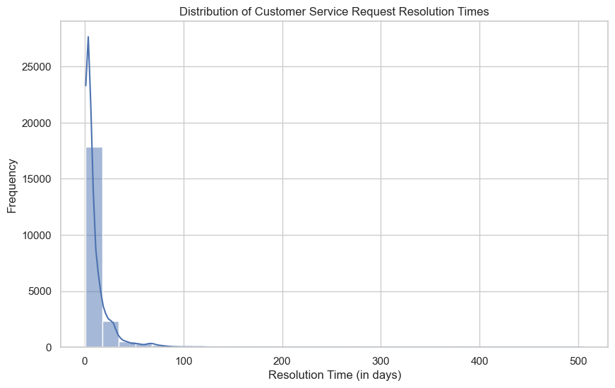

```
Environmental Resources Consumed - Basic Info:
<class 'pandas.core.frame.DataFrame'>
RangeIndex: 9474 entries, 0 to 9473
Data columns (total 12 columns):
 #   Column                            Non-Null Count  Dtype
---  ------                            --------------  -----
 0   branch                            9474 non-null   object
 1   asset_name                        9474 non-null   object
 2   resource_category                 9474 non-null   object
 3   resource_type                     9474 non-null   object
 4   amount                            9474 non-null   float64
 5   unit                              9474 non-null   object
 6   total_greenhouse_gases_(t_co2-e)  9474 non-null   float64
 7   billing_start_date                9474 non-null   object
 8   billing_end_date                  9474 non-null   object
 9   com_or_supply_chain               9474 non-null   object
 10  peak_amount                       9474 non-null   float64
 11  off-peak_amount                   9474 non-null   float64
dtypes: float64(4), object(8)
memory usage: 888.3+ KB
```

```
None
```

```
Environmental Resources Consumed - Statistical Summary:
```

|  | amount | total_greenhouse_gases_(t_co2-e) | peak_amount | off-peak_amount |
| --- | --- | --- | --- | --- |
| count | 9.474000e+03 | 9.474000e+03 | 9474.000000 | 9474.000000 |
| mean | 7.141096e+03 | 4.761649e+03 | 1177.887230 | 1348.908835 |
| std | 1.050493e+05 | 3.572745e+04 | 7363.440736 | 12022.095254 |
| min | 0.000000e+00 | 0.000000e+00 | 0.000000 | 0.000000 |
| 25% | 0.000000e+00 | 0.000000e+00 | 0.000000 | 0.000000 |
| 50% | 6.000000e+01 | 1.899467e+01 | 0.000000 | 0.000000 |
| 75% | 8.481231e+02 | 6.600000e+02 | 0.000000 | 0.000000 |
| max | 8.920000e+06 | 1.864778e+06 | 130348.998000 | 250208.680000 |

```
Columns 'date' or 'total_consumption' not found in Environmental Resources dataset.
Planned Capital Works - Basic Info:
<class 'pandas.core.frame.DataFrame'>
RangeIndex: 133 entries, 0 to 132
Data columns (total 14 columns):
 #   Column                                Non-Null Count  Dtype
---  ------                                --------------  -----
 0   financial_year                        133 non-null    object
 1   program                               133 non-null    object
 2   category                              133 non-null    object
 3   sub_category                          133 non-null    object
 4   expenditure_type                      133 non-null    object
 5   program_code                          133 non-null    object
 6   description                           133 non-null    object
 7   cash_($,000)                          133 non-null    int64
 8   grants_($,000)                        133 non-null    int64
 9   parking_levy_($,000)                  133 non-null    int64
 10  external_($,000)                      133 non-null    int64
 11  public_open_space_($,000)             133 non-null    int64
 12  proceeds_from_sale_of_assets_($,000)  133 non-null    int64
 13  total_funding_($,000)                 133 non-null    int64
dtypes: int64(7), object(7)
memory usage: 14.7+ KB
```

```
None
```

```
Planned Capital Works - Statistical Summary:
```

|  | cash_($,000) | grants_($,000) | parking_levy_($,000) | external_($,000) | public_open_space_($,000) | proceeds_from_sale_of_assets_($,000) | total_funding_($,000) |
| --- | --- | --- | --- | --- | --- | --- | --- |
| count | 1.330000e+02 | 133.000000 | 1.330000e+02 | 1.330000e+02 | 1.330000e+02 | 133.000000 | 1.330000e+02 |
| mean | 5.586208e+05 | 7499.624060 | 5.263158e+04 | 7.105263e+04 | 5.231198e+04 | 5037.593985 | 7.471542e+05 |
| std | 1.184064e+06 | 56791.818292 | 4.319755e+05 | 6.384525e+05 | 2.503872e+05 | 58096.367958 | 1.356737e+06 |
| min | 0.000000e+00 | 0.000000 | 0.000000e+00 | 0.000000e+00 | 0.000000e+00 | 0.000000 | 0.000000e+00 |
| 25% | 5.000000e+04 | 0.000000 | 0.000000e+00 | 0.000000e+00 | 0.000000e+00 | 0.000000 | 1.050000e+05 |
| 50% | 1.590000e+05 | 0.000000 | 0.000000e+00 | 0.000000e+00 | 0.000000e+00 | 0.000000 | 2.500000e+05 |
| 75% | 5.000000e+05 | 0.000000 | 0.000000e+00 | 0.000000e+00 | 0.000000e+00 | 0.000000 | 7.015450e+05 |
| max | 7.500000e+06 | 550000.000000 | 4.000000e+06 | 7.100000e+06 | 2.000000e+06 | 670000.000000 | 7.500000e+06 |

```
Column 'funding_source' not found in Capital Works dataset.
```

```python
# Set the style for seaborn plots
sns.set(style="whitegrid")

# Initial Exploratory Data Analysis (EDA)

# Customer Service Requests EDA
print("Customer Service Requests - Basic Info:")
display(customer_service_df.info())
print("Customer Service Requests - Statistical Summary:")
display(customer_service_df.describe())

# Visualize the distribution of request resolution times using 'days_to_complete'
plt.figure(figsize=(10, 6))
sns.histplot(customer_service_df['days_to_complete'], bins=30, kde=True)
plt.title('Distribution of Customer Service Request Resolution Times')
plt.xlabel('Resolution Time (in days)')
plt.ylabel('Frequency')
plt.show()

# Environmental Resources Consumed EDA
print("Environmental Resources Consumed - Basic Info:")
display(environmental_resources_df.info())
print("Environmental Resources Consumed - Statistical Summary:")
display(environmental_resources_df.describe())

# Visualize total resource consumption over time (check if 'date' and 'total_consumption' columns exist)
plt.figure(figsize=(12, 6))
if 'date' in environmental_resources_df.columns and 'total_consumption' in environmental_resources_df.columns:
    sns.lineplot(data=environmental_resources_df, x='date', y='total_consumption')
    plt.title('Total Environmental Resource Consumption Over Time')
    plt.xlabel('Date')
    plt.ylabel('Total Consumption')
    plt.xticks(rotation=45)
    plt.show()
else:
    print("Columns 'date' or 'total_consumption' not found in Environmental Resources dataset.")

# Planned Capital Works EDA
print("Planned Capital Works - Basic Info:")
display(capital_works_df.info())
print("Planned Capital Works - Statistical Summary:")
display(capital_works_df.describe())

# Visualize number of planned works by funding source (check if 'funding_source' column exists)
plt.figure(figsize=(14, 6))
if 'funding_source' in capital_works_df.columns:
    sns.countplot(data=capital_works_df, x='funding_source')
    plt.title('Number of Planned Works by Funding Source')
    plt.xlabel('Funding Source')
    plt.ylabel('Number of Projects')
    plt.xticks(rotation=45)
    plt.show()
else:
    print("Column 'funding_source' not found in Capital Works dataset.")
```

# **Seasonal Trend Analysis of Customer Service Requests**

## **Objective**

The goal of this analysis was to examine the monthly trends in customer service requests to uncover seasonal patterns. By visualizing the distribution of service requests over time, we can identify periods of increased demand, helping to optimize resource allocation and service planning.

## **Methodology**

1. **Data Preparation**:
   - The `date_received` column in the Customer Service Requests dataset was converted to a datetime format.
   - Year and month were extracted from the `date_received` column to enable grouping by time periods.
2. **Grouping and Aggregation**:
   - The data was grouped by `year` and `month` to calculate the total number of service requests for each period.
   - The resulting dataset provides the total request count for each month, enabling a clear view of seasonal trends.
3. **Visualization**:
   - A line plot was created to display the number of requests over time, with markers highlighting monthly data points.
   - The x-axis represents the `year-month` combination, while the y-axis indicates the `number of requests`.

## **Conclusion**

The next step is to investigate specific categories driving these trends and correlate them with environmental and operational factors to refine recommendations.

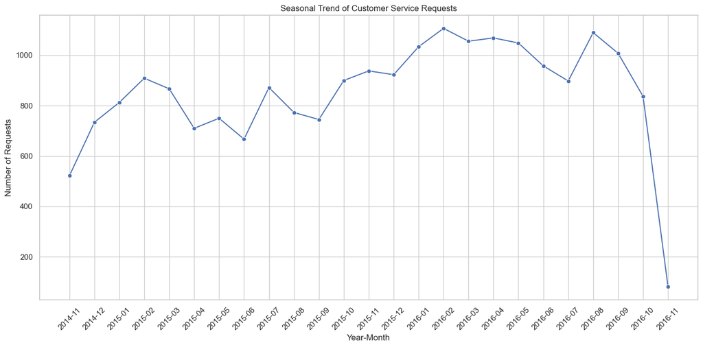

```python
# Convert 'date_received' to datetime format
customer_service_df['date_received'] = pd.to_datetime(customer_service_df['date_received'])

# Extract year and month for trend analysis
customer_service_df['year'] = customer_service_df['date_received'].dt.year
customer_service_df['month'] = customer_service_df['date_received'].dt.month

# Group by year and month to find the number of requests
monthly_trend = customer_service_df.groupby(['year', 'month']).size().reset_index(name='request_count')

# Plot the seasonal trend
plt.figure(figsize=(14, 7))
sns.lineplot(data=monthly_trend, x=monthly_trend.index, y='request_count', marker='o')
plt.xticks(ticks=monthly_trend.index, labels=[f"{row['year']}-{row['month']:02d}" for _, row in monthly_trend.iterrows()], rotation=45)
plt.title('Seasonal Trend of Customer Service Requests')
plt.xlabel('Year-Month')
plt.ylabel('Number of Requests')
plt.grid(True)
plt.tight_layout()
plt.show()
```

```
First few rows of merged_df after outer merge:
   year  month  request_count   amount  total_greenhouse_gases_(t_co2-e)  \
0  2011      5            0.0    0.000                          0.000000
1  2012      3            0.0  628.136                        842.402303
2  2012      8            0.0    0.000                          0.000000
3  2012     11            0.0   25.000                         49.346154
4  2013      2            0.0    0.000                          0.000000

        time
0 2011-05-01
1 2012-03-01
2 2012-08-01
3 2012-11-01
4 2013-02-01
```

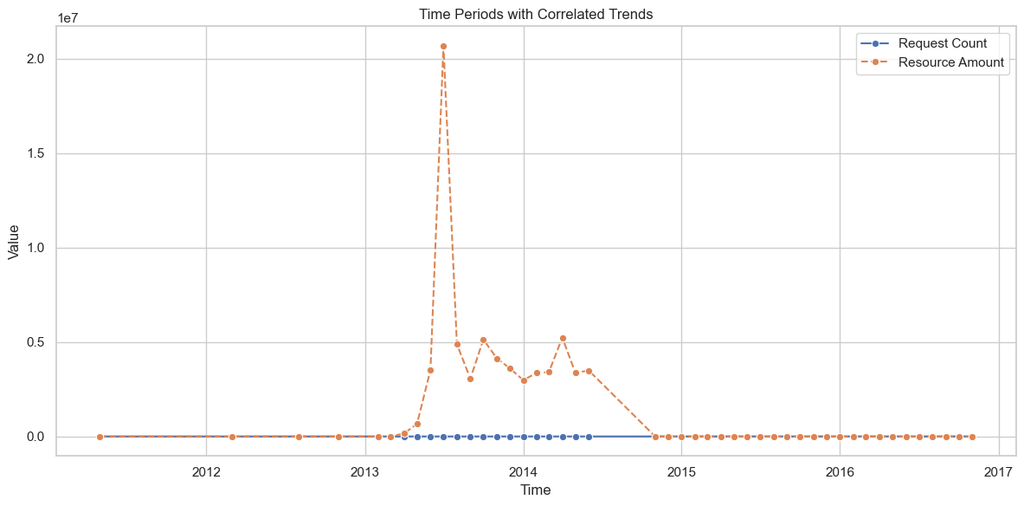

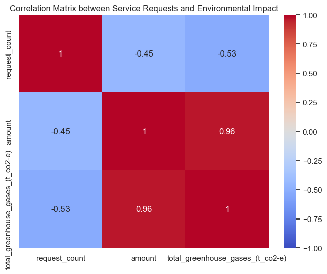

```python
# Merge datasets with an outer join to include all periods
merged_df = pd.merge(
    monthly_trend, monthly_env_consumption, on=['year', 'month'], how='outer'
)

# Fill missing values with 0
merged_df.fillna(0, inplace=True)

# Create a 'time' column for plotting
merged_df['time'] = pd.to_datetime(merged_df['year'].astype(str) + '-' + merged_df['month'].astype(str) + '-01')

# Debug merged DataFrame
print("First few rows of merged_df after outer merge:")
print(merged_df.head())

# Plot the trends over time
plt.figure(figsize=(12, 6))
sns.lineplot(data=merged_df, x='time', y='request_count', label='Request Count', marker='o')
sns.lineplot(data=merged_df, x='time', y='amount', label='Resource Amount', marker='o', linestyle='--')
plt.title('Time Periods with Correlated Trends')
plt.xlabel('Time')
plt.ylabel('Value')
plt.legend()
plt.grid(True)
plt.tight_layout()
plt.show()

# Calculate correlation matrix for all periods
correlation_matrix = merged_df[['request_count', 'amount', 'total_greenhouse_gases_(t_co2-e)']].corr()

# Plot the correlation matrix
plt.figure(figsize=(8, 6))
sns.heatmap(correlation_matrix, annot=True, cmap='coolwarm', vmin=-1, vmax=1)
plt.title('Correlation Matrix between Service Requests and Environmental Impact')
plt.show()
```

# **Correlation Analysis: Service Requests vs Environmental Resource Consumption**

## **Objective**

The objective of this analysis is to explore the relationship between the volume of service requests and environmental resource usage over time. This helps in identifying whether resource-intensive operations align with fluctuations in service demand, thereby uncovering potential inefficiencies or trends.

## **Key Findings**

### **Correlation Insights**

- **Request Count vs Resource Amount**:
  - A moderate negative correlation (-0.45), suggesting that periods of high resource consumption do not necessarily correspond to higher service demand.
- **Request Count vs Greenhouse Gases**:
  - A slightly stronger negative correlation (-0.53), highlighting that resource-intensive operations may not be directly tied to customer service trends.
- **Resource Amount vs Greenhouse Gases**:
  - A very strong positive correlation (0.96), confirming that resource consumption directly drives greenhouse gas emissions.

## **Conclusion**

This analysis underscores the need for:

- **Operational Optimization**: Aligning resource consumption with periods of high service demand to ensure efficient resource utilization.
- **Sustainability Measures**: Reducing resource usage and emissions during periods of low service demand to enhance sustainability.
- **Future Focus**: Investigating specific drivers of resource and emission spikes, such as large-scale projects or operational inefficiencies, to mitigate their environmental footprint.

These findings provide actionable insights for balancing operational efficiency and environmental sustainability.

```
Top Service Request Categories:
                            category  total_requests
5  Waste, Street Cleaning and Litter            9447
1                           Graffiti            5529
3                    Parks and Trees            5030
4                  Roads and Traffic             775
2                            Parking             305
0                  Asset maintenance             224
```

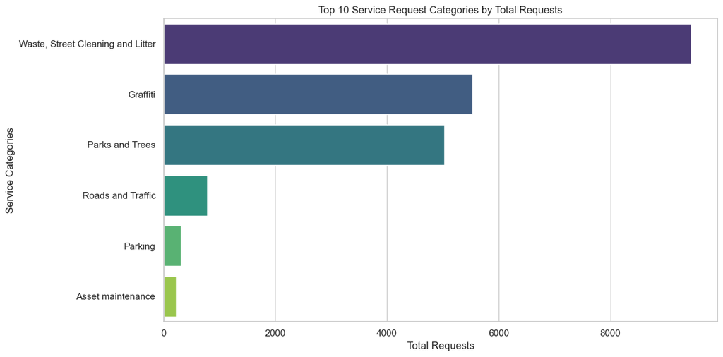

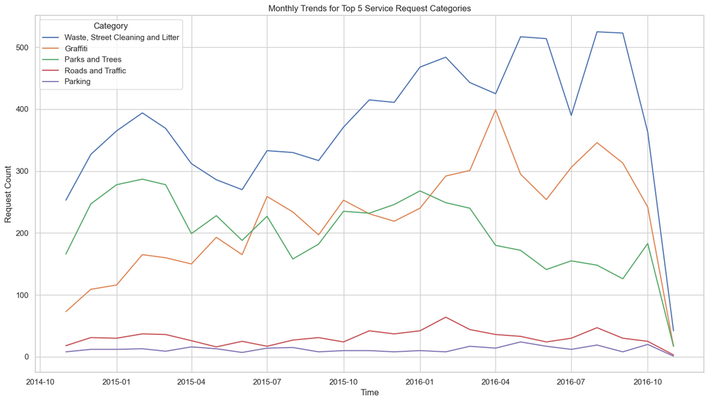

```
Correlation Matrix for Waste, Street Cleaning and Litter:
                                  request_count  amount  \
request_count                               1.0     NaN
amount                                      NaN     NaN
total_greenhouse_gases_(t_co2-e)            NaN     NaN

                                  total_greenhouse_gases_(t_co2-e)
request_count                                                  NaN
amount                                                         NaN
total_greenhouse_gases_(t_co2-e)                               NaN


Correlation Matrix for Graffiti:
                                  request_count  amount  \
request_count                               1.0     NaN
amount                                      NaN     NaN
total_greenhouse_gases_(t_co2-e)            NaN     NaN

                                  total_greenhouse_gases_(t_co2-e)
request_count                                                  NaN
amount                                                         NaN
total_greenhouse_gases_(t_co2-e)                               NaN


Correlation Matrix for Parks and Trees:
                                  request_count  amount  \
request_count                               1.0     NaN
amount                                      NaN     NaN
total_greenhouse_gases_(t_co2-e)            NaN     NaN

                                  total_greenhouse_gases_(t_co2-e)
request_count                                                  NaN
amount                                                         NaN
total_greenhouse_gases_(t_co2-e)                               NaN


Correlation Matrix for Roads and Traffic:
                                  request_count  amount  \
request_count                               1.0     NaN
amount                                      NaN     NaN
total_greenhouse_gases_(t_co2-e)            NaN     NaN

                                  total_greenhouse_gases_(t_co2-e)
request_count                                                  NaN
amount                                                         NaN
total_greenhouse_gases_(t_co2-e)                               NaN


Correlation Matrix for Parking:
                                  request_count  amount  \
request_count                               1.0     NaN
amount                                      NaN     NaN
total_greenhouse_gases_(t_co2-e)            NaN     NaN

                                  total_greenhouse_gases_(t_co2-e)
request_count                                                  NaN
amount                                                         NaN
total_greenhouse_gases_(t_co2-e)                               NaN
```

```python
# Group service requests by category and calculate total counts
category_counts = customer_service_df.groupby('category').size().reset_index(name='total_requests')

# Sort categories by the number of requests
category_counts = category_counts.sort_values(by='total_requests', ascending=False)

# Display top categories
print("Top Service Request Categories:")
print(category_counts.head(10))

# Plot top 10 categories
plt.figure(figsize=(12, 6))
sns.barplot(data=category_counts.head(10), x='total_requests', y='category', palette='viridis')
plt.title('Top 10 Service Request Categories by Total Requests')
plt.xlabel('Total Requests')
plt.ylabel('Service Categories')
plt.tight_layout()
plt.show()

# Correlation between top categories and resource consumption
# Merge category data with monthly resource consumption based on time
customer_service_df['date_received'] = pd.to_datetime(customer_service_df['date_received'])
customer_service_df['year'] = customer_service_df['date_received'].dt.year
customer_service_df['month'] = customer_service_df['date_received'].dt.month

# Group service requests by category, year, and month to align with merged_df
category_monthly = customer_service_df.groupby(['category', 'year', 'month']).size().reset_index(name='request_count')

# Merge with the existing merged_df for correlation analysis
category_resource_df = pd.merge(
    category_monthly,
    merged_df[['year', 'month', 'amount', 'total_greenhouse_gases_(t_co2-e)']],
    on=['year', 'month'],
    how='inner'
)

# Filter the top 5 categories for analysis
top_categories = category_counts['category'].head(5).tolist()
filtered_df = category_resource_df[category_resource_df['category'].isin(top_categories)]

# Plot resource trends for top 5 categories
plt.figure(figsize=(14, 8))
for category in top_categories:
    subset = filtered_df[filtered_df['category'] == category]
    sns.lineplot(data=subset, x=pd.to_datetime(subset['year'].astype(str) + '-' + subset['month'].astype(str) + '-01'),
                 y='request_count', label=category)

plt.title('Monthly Trends for Top 5 Service Request Categories')
plt.xlabel('Time')
plt.ylabel('Request Count')
plt.legend(title='Category')
plt.grid(True)
plt.tight_layout()
plt.show()

# Calculate correlations between resource usage and request counts for top categories
for category in top_categories:
    subset = filtered_df[filtered_df['category'] == category]
    correlation = subset[['request_count', 'amount', 'total_greenhouse_gases_(t_co2-e)']].corr()
    print(f"Correlation Matrix for {category}:")
    print(correlation)
    print("\n")
```

# **Seasonal Analysis of Top Service Request Categories**

## **Objective**

The goal of this analysis is to identify seasonal trends in customer service requests for the top two service categories: **Waste, Street Cleaning and Litter** and **Graffiti**. This analysis provides insights into how the demand for these services fluctuates throughout the year, enabling targeted resource planning and operational efficiency.

## **Methodology**

1. **Data Filtering**:
   - The dataset was filtered to include only the top two service request categories: **Waste, Street Cleaning and Litter** and **Graffiti**.
   - For each request, the month of occurrence was extracted to analyze seasonal patterns.
2. **Grouping**:
   - Requests were grouped by **category** and **month** to calculate the total number of requests for each category in each month across all years.
3. **Visualization**:
   - A line plot was used to represent the monthly trends for each category, highlighting seasonal peaks and troughs.

## **Conclusion**

This seasonal analysis highlights distinct patterns in customer service demands for top service categories. By aligning resource planning and operational efforts with these trends, the City of Melbourne can enhance service delivery, optimize costs, and improve urban management.

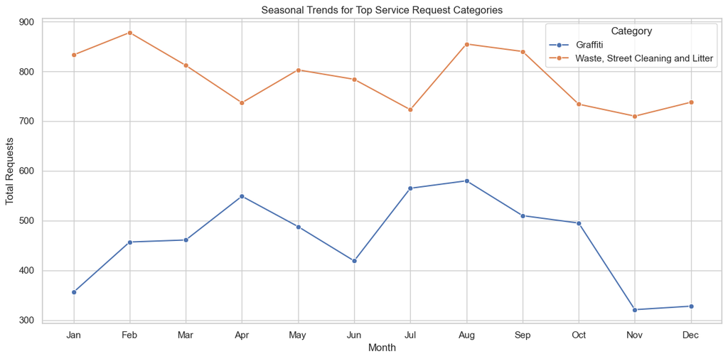

```python
# Import necessary libraries
import matplotlib.pyplot as plt
import seaborn as sns
import pandas as pd

# Filter data for the top 2 categories
top_categories_seasonal = ["Waste, Street Cleaning and Litter", "Graffiti"]
filtered_category_df = customer_service_df[customer_service_df['category'].isin(top_categories_seasonal)]

# Group by category and month to calculate total requests for each month across years
filtered_category_df['month'] = filtered_category_df['date_received'].dt.month
seasonal_trends = filtered_category_df.groupby(['category', 'month']).size().reset_index(name='total_requests')

# Plot seasonal trends
plt.figure(figsize=(12, 6))
sns.lineplot(data=seasonal_trends, x='month', y='total_requests', hue='category', marker='o')
plt.title('Seasonal Trends for Top Service Request Categories')
plt.xlabel('Month')
plt.ylabel('Total Requests')
plt.xticks(ticks=range(1, 13), labels=['Jan', 'Feb', 'Mar', 'Apr', 'May', 'Jun', 'Jul', 'Aug', 'Sep', 'Oct', 'Nov', 'Dec'])
plt.legend(title='Category')
plt.grid(True)
plt.tight_layout()
plt.show()
```

# **Suburb Analysis of Service Requests**

## **Objective**

The aim of this analysis is to identify the top suburbs generating the highest number of service requests for the two leading categories: **Waste, Street Cleaning and Litter** and **Graffiti**. This insight is crucial for understanding localized demand patterns and optimizing resource allocation for these services.

## **Methodology**

1. **Data Filtering**:
   - The dataset was filtered to include only the top two categories: **Waste, Street Cleaning and Litter** and **Graffiti**.
   - Suburbs were grouped by category to calculate the total number of requests for each suburb.
2. **Top Suburb Identification**:
   - For each category, the top 10 suburbs with the highest total requests were identified and sorted.
3. **Visualization**:
   - Bar plots were created to visualize the distribution of total requests across the top 10 suburbs for each category.
   - Additionally, a heatmap was generated to provide a comprehensive view of service demand across suburbs and categories.

## **Key Findings**

### **Waste, Street Cleaning and Litter**

- **Top Suburb**: Melbourne
- Other prominent suburbs include **North Melbourne**, **Carlton**, and **Kensington**.
- Suburbs like **West Melbourne** and **Docklands** also generate significant requests, indicating widespread demand across various city regions.

### **Graffiti**

- **Top Suburb**: Melbourne
- Suburbs like **Carlton**, **North Melbourne**, and **Kensington** show high graffiti service demand, consistent with urban areas prone to graffiti incidents.
- Suburbs with lower requests include **Southbank** and **South Yarra**, suggesting less graffiti activity in these areas.

## **Insights and Recommendations**

1. **Localized Resource Allocation**:
   - For **Waste, Street Cleaning and Litter**, deploy additional cleaning resources to Melbourne, North Melbourne, and Carlton to handle peak demand.
   - For **Graffiti**, focus on proactive graffiti removal measures in Melbourne and Carlton, where incidents are most frequent.
2. **Suburb-Specific Strategies**:
   - Tailor cleaning schedules to align with the peak demand periods observed in top suburbs for **Waste, Street Cleaning and Litter**.
   - Implement community awareness campaigns in high-demand graffiti suburbs to prevent graffiti incidents.
3. **Heatmap Insights**:
   - The heatmap revealed spatial clustering of demand, particularly in Melbourne and surrounding suburbs, underscoring the need for a centralized but adaptable operational approach.

## **Conclusion**

The suburb-level analysis of service requests highlights significant geographic variations in demand for the top two categories. This insight allows for targeted resource planning and operational efficiency improvements, enhancing service delivery in high-demand suburbs.

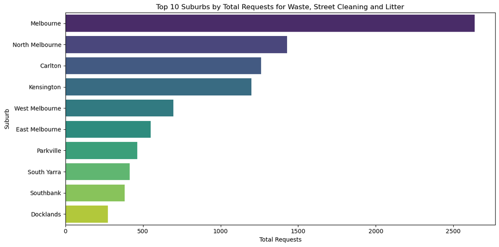

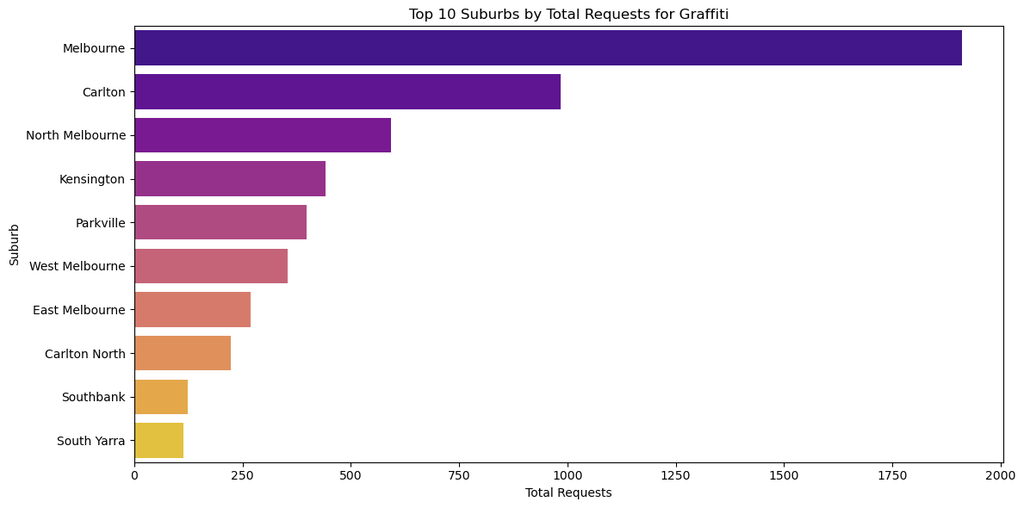

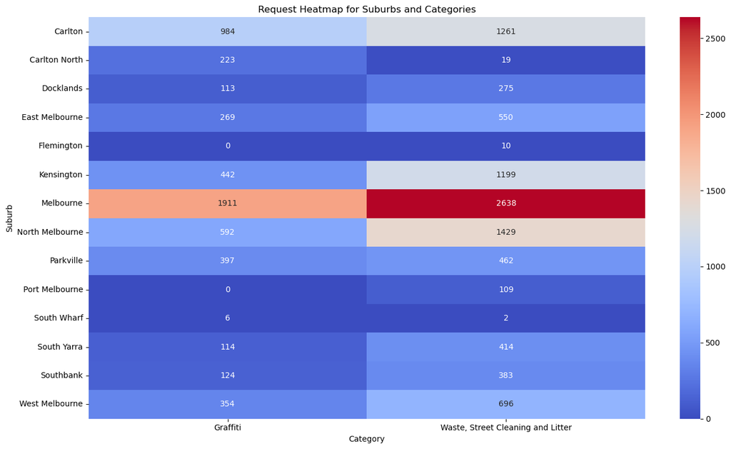

```python
# Filter data for the top 2 categories
top_categories_suburb = ["Waste, Street Cleaning and Litter", "Graffiti"]
filtered_suburb_df = customer_service_df[customer_service_df['category'].isin(top_categories_suburb)]

# Group by suburb and category to calculate total requests
suburb_trends = filtered_suburb_df.groupby(['suburb', 'category']).size().reset_index(name='total_requests')

# Sort and filter for top suburbs for each category
top_suburbs_waste = suburb_trends[suburb_trends['category'] == "Waste, Street Cleaning and Litter"].sort_values(by='total_requests', ascending=False).head(10)
top_suburbs_graffiti = suburb_trends[suburb_trends['category'] == "Graffiti"].sort_values(by='total_requests', ascending=False).head(10)

# Plot top suburbs for Waste, Street Cleaning and Litter
plt.figure(figsize=(12, 6))
sns.barplot(data=top_suburbs_waste, x='total_requests', y='suburb', palette='viridis')
plt.title('Top 10 Suburbs by Total Requests for Waste, Street Cleaning and Litter')
plt.xlabel('Total Requests')
plt.ylabel('Suburb')
plt.tight_layout()
plt.show()

# Plot top suburbs for Graffiti
plt.figure(figsize=(12, 6))
sns.barplot(data=top_suburbs_graffiti, x='total_requests', y='suburb', palette='plasma')
plt.title('Top 10 Suburbs by Total Requests for Graffiti')
plt.xlabel('Total Requests')
plt.ylabel('Suburb')
plt.tight_layout()
plt.show()

# Suburb analysis: Heatmap for top suburbs (optional)
# Pivot data for a heatmap
heatmap_data = suburb_trends.pivot(index="suburb", columns="category", values="total_requests").fillna(0)

# Plot the heatmap
plt.figure(figsize=(14, 8))
sns.heatmap(heatmap_data, annot=True, fmt="g", cmap="coolwarm", cbar=True)
plt.title('Request Heatmap for Suburbs and Categories')
plt.xlabel('Category')
plt.ylabel('Suburb')
plt.tight_layout()
plt.show()
```

# **Temporal Analysis of Suburb Trends**

## **Objective**

The objective of this analysis is to explore the temporal dynamics of service requests across the top suburbs for **Waste, Street Cleaning and Litter** and **Graffiti** categories. This provides insight into how demand patterns evolve over time, enabling better planning and resource allocation.

## **Methodology**

1. **Suburb Selection**:
   - The top 10 suburbs for each category were identified from the previous suburb analysis.
   - These suburbs were filtered for temporal trend analysis.
2. **Data Transformation**:
   - The `date_received` column was converted into a `year_month` period format to group requests by month and year.
   - Total requests were calculated for each suburb-category combination on a monthly basis.
3. **Visualization**:
   - Separate line plots were generated for each category, showing monthly trends for the top suburbs.

## **Conclusion**

Temporal trends provide valuable insights into the evolution of service demand across suburbs. This analysis highlights the importance of dynamic resource planning and targeted interventions to maintain service efficiency during high-demand periods.

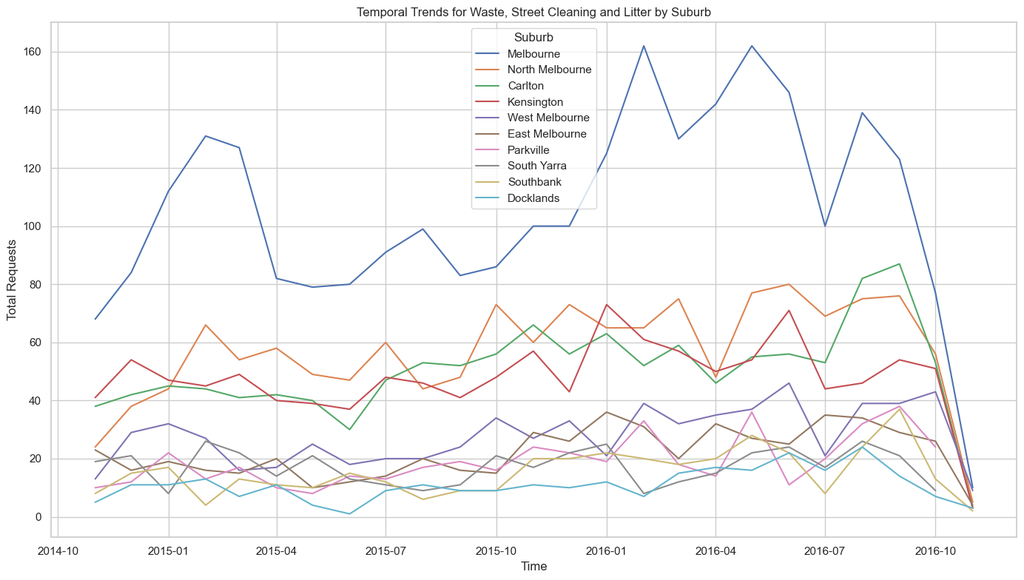

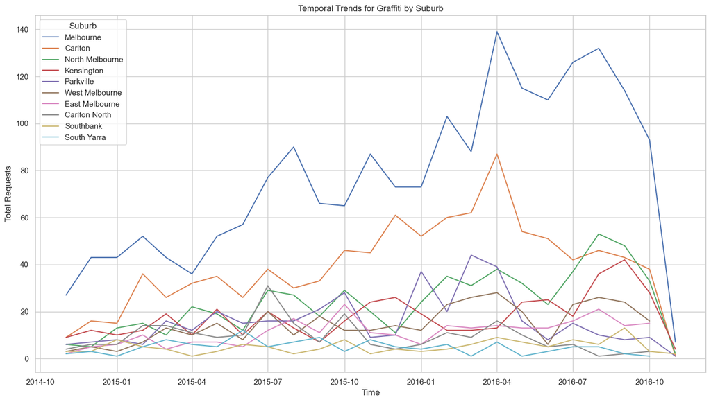

```python
# Select top suburbs for Waste and Graffiti categories
top_waste_suburbs = top_suburbs_waste['suburb'].tolist()
top_graffiti_suburbs = top_suburbs_graffiti['suburb'].tolist()

# Filter data for these suburbs and categories
filtered_temporal_df = filtered_suburb_df[
    filtered_suburb_df['suburb'].isin(top_waste_suburbs + top_graffiti_suburbs)
]

# Group by suburb, category, year, and month to calculate monthly request counts
filtered_temporal_df['year_month'] = filtered_temporal_df['date_received'].dt.to_period('M')
temporal_trends = filtered_temporal_df.groupby(['suburb', 'category', 'year_month']).size().reset_index(name='total_requests')

# Convert year_month to datetime for plotting
temporal_trends['year_month'] = temporal_trends['year_month'].dt.to_timestamp()

# Separate trends for Waste and Graffiti for clearer plots
waste_trends = temporal_trends[temporal_trends['category'] == "Waste, Street Cleaning and Litter"]
graffiti_trends = temporal_trends[temporal_trends['category'] == "Graffiti"]

# Plot temporal trends for Waste by suburb
plt.figure(figsize=(14, 8))
for suburb in top_waste_suburbs:
    subset = waste_trends[waste_trends['suburb'] == suburb]
    sns.lineplot(data=subset, x='year_month', y='total_requests', label=suburb)

plt.title('Temporal Trends for Waste, Street Cleaning and Litter by Suburb')
plt.xlabel('Time')
plt.ylabel('Total Requests')
plt.legend(title='Suburb')
plt.grid(True)
plt.tight_layout()
plt.show()

# Plot temporal trends for Graffiti by suburb
plt.figure(figsize=(14, 8))
for suburb in top_graffiti_suburbs:
    subset = graffiti_trends[graffiti_trends['suburb'] == suburb]
    sns.lineplot(data=subset, x='year_month', y='total_requests', label=suburb)

plt.title('Temporal Trends for Graffiti by Suburb')
plt.xlabel('Time')
plt.ylabel('Total Requests')
plt.legend(title='Suburb')
plt.grid(True)
plt.tight_layout()
plt.show()
```